# This dataset includes information about individuals rides made in a bike- sharing system covering the area of San Francisco Bay in the month of February 2019.

```python
# import the neccessary libraries

import pandas as pd
import matplotlib.pyplot as plt
import numpy as np
import seaborn as sb

%matplotlib inline
```

# Gathering Data

```python
# load in dataset into pandas dataframe
my_data = pd.read_csv('201902-fordgobike-tripdata.csv')
```

```python
my_data.sample(6)
```

|  | duration_sec | start_time | end_time | start_station_id | start_station_name | start_station_latitude | start_station_longitude | end_station_id | end_station_name | end_station_latitude | end_station_longitude | bike_id | user_type | member_birth_year | member_gender | bike_share_for_all_trip |
| --- | --- | --- | --- | --- | --- | --- | --- | --- | --- | --- | --- | --- | --- | --- | --- | --- |
| 69692 | 732 | 2019-02-19 19:02:30.8750 | 2019-02-19 19:14:43.6740 | 24.0 | Spear St at Folsom St | 37.789677 | -122.390428 | 368.0 | Myrtle St at Polk St | 37.785434 | -122.419622 | 5284 | Subscriber | 1986.0 | Male | No |
| 94437 | 98 | 2019-02-15 16:33:02.7030 | 2019-02-15 16:34:41.0840 | 97.0 | 14th St at Mission St | 37.768265 | -122.420110 | 223.0 | 16th St Mission BART Station 2 | 37.764765 | -122.420091 | 6413 | Subscriber | 1975.0 | Male | No |
| 68000 | 279 | 2019-02-20 07:00:40.4830 | 2019-02-20 07:05:19.5020 | 124.0 | 19th St at Florida St | 37.760447 | -122.410807 | 89.0 | Division St at Potrero Ave | 37.769218 | -122.407646 | 4517 | Subscriber | 1979.0 | Male | No |
| 113647 | 738 | 2019-02-12 11:24:42.2190 | 2019-02-12 11:37:01.2030 | 102.0 | Irwin St at 8th St | 37.766883 | -122.399579 | 59.0 | S Van Ness Ave at Market St | 37.774814 | -122.418954 | 5304 | Subscriber | 1979.0 | Male | No |
| 114000 | 510 | 2019-02-12 10:15:41.6350 | 2019-02-12 10:24:12.1750 | 3.0 | Powell St BART Station (Market St at 4th St) | 37.786375 | -122.404904 | 17.0 | Embarcadero BART Station (Beale St at Market St) | 37.792251 | -122.397086 | 4404 | Subscriber | 1985.0 | Male | No |
| 75586 | 88 | 2019-02-19 09:05:10.7130 | 2019-02-19 09:06:39.0560 | 239.0 | Bancroft Way at Telegraph Ave | 37.868813 | -122.258764 | 243.0 | Bancroft Way at College Ave | 37.869360 | -122.254337 | 5177 | Subscriber | 1997.0 | Male | Yes |

# Data Wrangling

```python
# how many rows and columns

my_data.shape
```

```
(183412, 16)
```

```python
# checking if there are duplicates

sum(my_data.duplicated())
```

```
0
```

```python
# Check null value for each column
my_data.isna().sum()
```

```
duration_sec                  0
start_time                    0
end_time                      0
start_station_id            197
start_station_name          197
start_station_latitude        0
start_station_longitude       0
end_station_id              197
end_station_name            197
end_station_latitude          0
end_station_longitude         0
bike_id                       0
user_type                     0
member_birth_year          8265
member_gender              8265
bike_share_for_all_trip       0
dtype: int64
```

```python
#let drop the na from the dataset

my_data.dropna(inplace = True)
```

```python
# overview of the composition of data

my_data.info()
```

```
<class 'pandas.core.frame.DataFrame'>
Int64Index: 174952 entries, 0 to 183411
Data columns (total 16 columns):
 #   Column                   Non-Null Count   Dtype
---  ------                   --------------   -----
 0   duration_sec             174952 non-null  int64
 1   start_time               174952 non-null  object
 2   end_time                 174952 non-null  object
 3   start_station_id         174952 non-null  float64
 4   start_station_name       174952 non-null  object
 5   start_station_latitude   174952 non-null  float64
 6   start_station_longitude  174952 non-null  float64
 7   end_station_id           174952 non-null  float64
 8   end_station_name         174952 non-null  object
 9   end_station_latitude     174952 non-null  float64
 10  end_station_longitude    174952 non-null  float64
 11  bike_id                  174952 non-null  int64
 12  user_type                174952 non-null  object
 13  member_birth_year        174952 non-null  float64
 14  member_gender            174952 non-null  object
 15  bike_share_for_all_trip  174952 non-null  object
dtypes: float64(7), int64(2), object(7)
memory usage: 22.7+ MB
```

```python
# changing data type of start_time and end_time to datetime.

my_data['start_time'] = pd.to_datetime(my_data.start_time)
my_data['end_time'] = pd.to_datetime(my_data.end_time)


# changing datatype to boolean

my_data.bike_share_for_all_trip = (my_data.bike_share_for_all_trip == 'Yes')
```

```python
# let check if it changed

my_data.info()
```

```
<class 'pandas.core.frame.DataFrame'>
Int64Index: 174952 entries, 0 to 183411
Data columns (total 16 columns):
 #   Column                   Non-Null Count   Dtype
---  ------                   --------------   -----
 0   duration_sec             174952 non-null  int64
 1   start_time               174952 non-null  datetime64[ns]
 2   end_time                 174952 non-null  datetime64[ns]
 3   start_station_id         174952 non-null  float64
 4   start_station_name       174952 non-null  object
 5   start_station_latitude   174952 non-null  float64
 6   start_station_longitude  174952 non-null  float64
 7   end_station_id           174952 non-null  float64
 8   end_station_name         174952 non-null  object
 9   end_station_latitude     174952 non-null  float64
 10  end_station_longitude    174952 non-null  float64
 11  bike_id                  174952 non-null  int64
 12  user_type                174952 non-null  object
 13  member_birth_year        174952 non-null  float64
 14  member_gender            174952 non-null  object
 15  bike_share_for_all_trip  174952 non-null  bool
dtypes: bool(1), datetime64[ns](2), float64(7), int64(2), object(4)
memory usage: 21.5+ MB
```

```python
# let create new columns from start_time

my_data['start_year']= my_data['start_time'].dt.year
my_data['start_month']= my_data['start_time'].dt.month_name()
my_data['start_day']= my_data['start_time'].dt.day
my_data['Dayofweek']=my_data['start_time'].dt.day_name()
my_data['start_hour'] = my_data.start_time.dt.hour


# convert seconds to minutes
my_data['duration_minutes'] = my_data['duration_sec']/60
```

```python
# test for the addition of 5 new columns

my_data.info()
```

```
<class 'pandas.core.frame.DataFrame'>
Int64Index: 174952 entries, 0 to 183411
Data columns (total 22 columns):
 #   Column                   Non-Null Count   Dtype
---  ------                   --------------   -----
 0   duration_sec             174952 non-null  int64
 1   start_time               174952 non-null  datetime64[ns]
 2   end_time                 174952 non-null  datetime64[ns]
 3   start_station_id         174952 non-null  float64
 4   start_station_name       174952 non-null  object
 5   start_station_latitude   174952 non-null  float64
 6   start_station_longitude  174952 non-null  float64
 7   end_station_id           174952 non-null  float64
 8   end_station_name         174952 non-null  object
 9   end_station_latitude     174952 non-null  float64
 10  end_station_longitude    174952 non-null  float64
 11  bike_id                  174952 non-null  int64
 12  user_type                174952 non-null  object
 13  member_birth_year        174952 non-null  float64
 14  member_gender            174952 non-null  object
 15  bike_share_for_all_trip  174952 non-null  bool
 16  start_year               174952 non-null  int64
 17  start_month              174952 non-null  object
 18  start_day                174952 non-null  int64
 19  Dayofweek                174952 non-null  object
 20  start_hour               174952 non-null  int64
 21  duration_minutes         174952 non-null  float64
dtypes: bool(1), datetime64[ns](2), float64(8), int64(5), object(6)
memory usage: 29.5+ MB
```

```python
# dropping some unuseful columns in the dataset


columns = ['start_station_latitude', 'start_station_longitude', 'end_station_latitude', 'end_station_longitude']

#remove columns

my_data.drop(columns, axis=1, inplace= True)

my_data.columns
```

```
Index(['duration_sec', 'start_time', 'end_time', 'start_station_id',
       'start_station_name', 'end_station_id', 'end_station_name', 'bike_id',
       'user_type', 'member_birth_year', 'member_gender',
       'bike_share_for_all_trip', 'start_year', 'start_month', 'start_day',
       'Dayofweek', 'start_hour', 'duration_minutes'],
      dtype='object')
```

```python
my_data['member_gender'].value_counts()
```

```
Male      130500
Female     40805
Other       3647
Name: member_gender, dtype: int64
```

```python
# dropping Other from the member_gender column

filt = my_data['member_gender'] == 'Other'

my_data = my_data.drop(index=my_data[filt].index)
```

```python
#checking if the code work by dropping the other

my_data.sample(7)
```

|  | duration_sec | start_time | end_time | start_station_id | start_station_name | end_station_id | end_station_name | bike_id | user_type | member_birth_year | member_gender | bike_share_for_all_trip | start_year | start_month | start_day | Dayofweek | start_hour | duration_minutes |
| --- | --- | --- | --- | --- | --- | --- | --- | --- | --- | --- | --- | --- | --- | --- | --- | --- | --- | --- |
| 1673 | 480 | 2019-02-28 18:49:47.327 | 2019-02-28 18:57:47.388 | 245.0 | Downtown Berkeley BART | 266.0 | Parker St at Fulton St | 5896 | Subscriber | 1988.0 | Male | False | 2019 | February | 28 | Thursday | 18 | 8.000000 |
| 140214 | 569 | 2019-02-07 19:21:30.668 | 2019-02-07 19:31:00.345 | 323.0 | Broadway at Kearny | 6.0 | The Embarcadero at Sansome St | 4956 | Subscriber | 1987.0 | Female | False | 2019 | February | 7 | Thursday | 19 | 9.483333 |
| 67104 | 233 | 2019-02-20 08:19:20.762 | 2019-02-20 08:23:14.542 | 61.0 | Howard St at 8th St | 90.0 | Townsend St at 7th St | 6483 | Subscriber | 1980.0 | Male | False | 2019 | February | 20 | Wednesday | 8 | 3.883333 |
| 61469 | 591 | 2019-02-20 17:39:36.909 | 2019-02-20 17:49:27.915 | 163.0 | Lake Merritt BART Station | 197.0 | El Embarcadero at Grand Ave | 4662 | Subscriber | 1981.0 | Female | False | 2019 | February | 20 | Wednesday | 17 | 9.850000 |
| 26604 | 294 | 2019-02-25 11:52:12.537 | 2019-02-25 11:57:06.985 | 85.0 | Church St at Duboce Ave | 53.0 | Grove St at Divisadero | 5814 | Subscriber | 1931.0 | Male | False | 2019 | February | 25 | Monday | 11 | 4.900000 |
| 132457 | 150 | 2019-02-09 03:17:02.380 | 2019-02-09 03:19:33.229 | 244.0 | Shattuck Ave at Hearst Ave | 256.0 | Hearst Ave at Euclid Ave | 4880 | Subscriber | 1997.0 | Male | False | 2019 | February | 9 | Saturday | 3 | 2.500000 |
| 43787 | 932 | 2019-02-22 15:56:32.529 | 2019-02-22 16:12:04.815 | 126.0 | Esprit Park | 15.0 | San Francisco Ferry Building (Harry Bridges Pl... | 5811 | Subscriber | 1970.0 | Male | False | 2019 | February | 22 | Friday | 15 | 15.533333 |

# UNIVARIATE EXPLORATION

## QUESTION 1 : How many Customers and Subscribers are the members of the bike riding system.

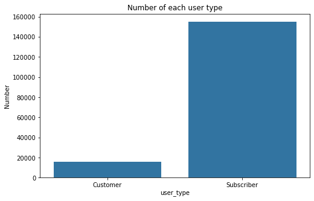

```python
#creating function for the labels of visuals called plot_label

def plot_label(title,xlabel,ylabel):
    ''''
    This is function for labelling
    '''
    plt.title(title)
    plt.xlabel(xlabel)
    plt.ylabel(ylabel)
    plt.show()


    # Show number of user using countplot

plt.figure(figsize=(8,5))
base_color = sb.color_palette()[0]
ax = sb.countplot(data=my_data, x ='user_type', color=base_color)
plot_label('Number of each user type', 'user_type','Number')
```

## The bar plot shows that Subscriber clients are more than Customer clients, the Customer clients are less than 20,000. while Subscriber clients is almost 160,000.

## QUESTION 2 : What are the percentage of each rider.

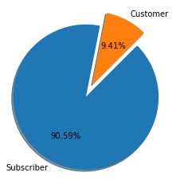

```python
# plot a pie chart
user_category = my_data['user_type'].value_counts()
plt.pie(user_category, explode =  (0, 0.2), labels = user_category.index, shadow = True, startangle = 45,
        counterclock = False, autopct='%1.2f%%');
plt.axis('square')
plt.show()
```

## As shown from above, the percentage of Subscriber is 90.6% whole that of Customer is 9.4%.

## QUESTION 3: Which gender has higher number of riders.

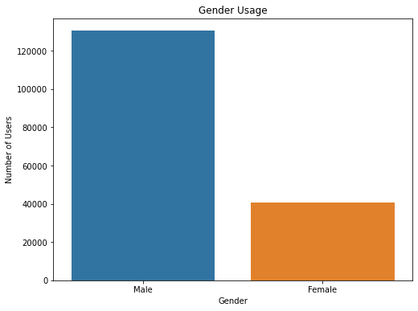

```python
# barplot of gender usage
plt.figure(figsize=(8,6))
sb.countplot(data = my_data, x = 'member_gender')
plot_label('Gender Usage','Gender','Number of Users');
```

## Male has higher number compare to Female, number of Male is more than 120,000 while female is around 40,000.That is Male number is triple the Female number.

## QUESTION 4: Which of the end stations is the most popular?

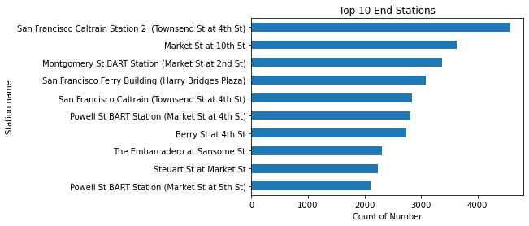

```python
my_data.end_station_name.value_counts(ascending=True).tail(10).plot.barh()
plot_label('Top 10 End Stations','Count of Number','Station name')
```

## San Francisco Station 2 is the most popular end Station followed by Market St at 10th St while Powell St BART Start is the least in top ten end Station.

## QUESTION 5: Which of the start stations is the most popular?

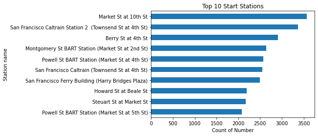

```python
my_data.start_station_name.value_counts(ascending=True).tail(10).plot.barh()
plot_label('Top 10 Start Stations','Count of Number','Station name');
```

## Market St at 10th st is the most popular start station followed by San Francisco station 2 while Powell st BART is the least popular start station in top 10.

# Bivariate Exploration

## QUESTION 6: Who among the the gender spend most time on riding bike?

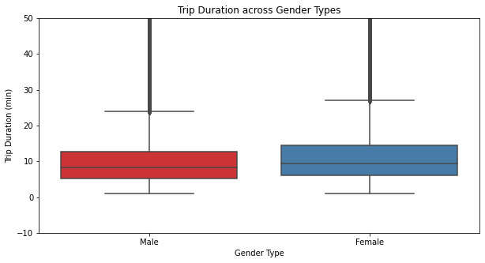

```python
plt.figure(figsize = [10, 5])
sb.boxplot(x='member_gender', y='duration_minutes', data = my_data, palette ='Set1', order=['Male', 'Female'])
plt.ylim(-10, 50)
plot_label('Trip Duration across Gender Types','Gender Type','Trip Duration (min)')
```

## The average time spent by Female is more greater than Male, The boxplot does show that female gender has a higher trip duration than male.

## Question 7: Which of the gender shared the ride with other when riding.

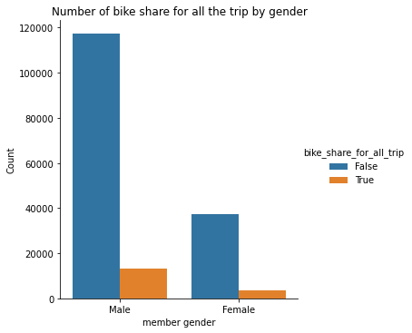

```python
sb.catplot(x='member_gender',hue='bike_share_for_all_trip',data=my_data,kind='count')
plot_label('Number of bike share for all the trip by gender','member gender','Count');
```

## The viz showed that Male gender share more bike than their Female counterpart, the count bike share Male almost triple the Female one.

## Question 8: What is average duration in minute for each gender during riding

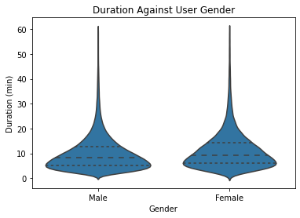

```python
#query the data for duration only below 1 hour to focus the data
my_data_dur = my_data.query("duration_minutes < 60")

# plot relationship between gender and duration
base_color = sb.color_palette()[0]
sb.violinplot(data=my_data_dur, x='member_gender', y='duration_minutes', color=base_color, inner='quartile')
plot_label('Duration Against User Gender','Gender','Duration (min)');
```

## The plot looks similar for these two gender categories, with the median all similar around 10 minutes,but their third quarter is slightly difference.

## Question 9: Which of the user type has higher duration during riding.

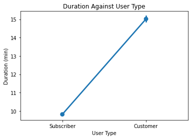

```python
# plot relationship between user type and duration
base_color = sb.color_palette()[0]
sb.pointplot(data=my_data_dur, x='user_type', y='duration_minutes', color=base_color, inner='quartile')
plot_label('Duration Against User Type','User Type','Duration (min)');
```

## Question 10: When is likely for each rider love to start riding.

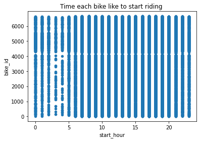

```python
my_data.plot.scatter('start_hour','bike_id')
plot_label('Time each bike like to start riding ','start_hour','bike_id');
```

## Question 11: Who has average mean between the gender per week.

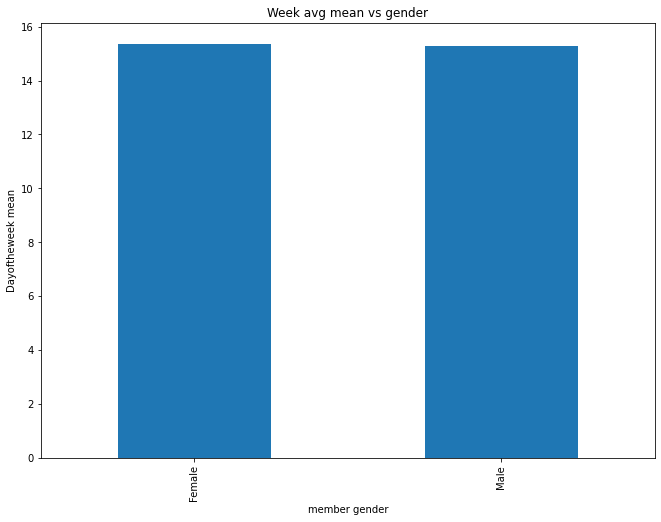

```python
# let plot bar chart to show case the value
plt.figure(figsize=[11, 8])
my_data.groupby('member_gender')['start_day'].mean().plot.bar()
plot_label('Week avg mean vs gender','member gender','Dayoftheweek mean');
```

# Multivariate Exploration

## Question 12: Which day with station id has member gender highest number?

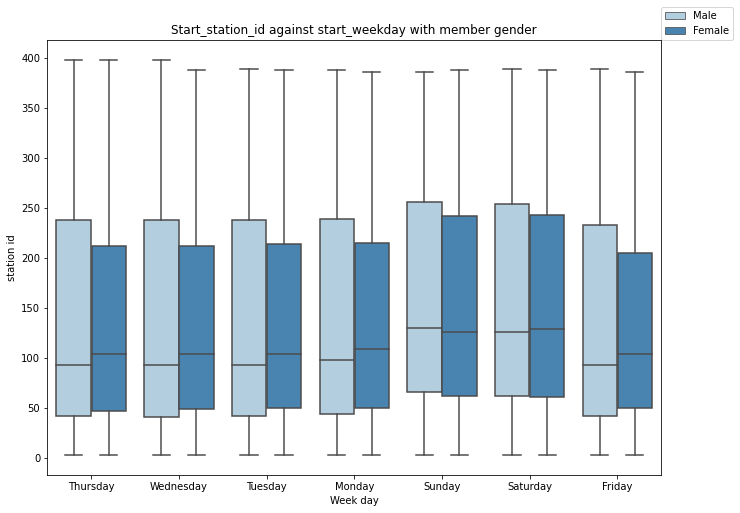

```python
plt.figure(figsize=[11, 8])
sb.boxplot(data = my_data, x = 'Dayofweek', y = 'start_station_id', hue = 'member_gender', palette = 'Blues')
plt.legend(loc=(1,1))
plot_label('Start_station_id against start_weekday with member gender','Week day','station id');
```

## Question 13: Does bike share during the week with certain start station id higher than the other.

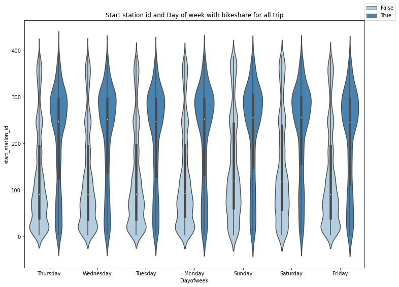

```python
plt.figure(figsize=[12, 9])
sb.violinplot(data = my_data, x = 'Dayofweek', y = 'start_station_id', hue = 'bike_share_for_all_trip', palette = 'Blues')
plt.legend(loc=(1,1))
plot_label('Start station id and Day of week with bikeshare for all trip','Dayofweek','start_station_id');
```

## Start station id all have the same third quarter values for true bike share during the weekday but different value for the false bike share.

## Question 14: How does each client fare with start station during the week.

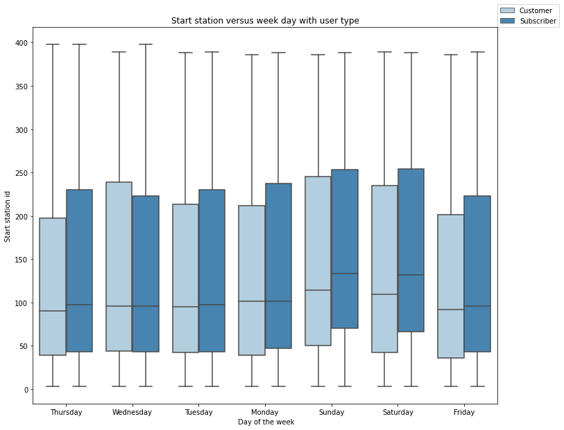

```python
plt.figure(figsize=[12, 10])
sb.boxplot(data = my_data, x = 'Dayofweek', y = 'start_station_id', hue = 'user_type', palette = 'Blues')
plt.legend(loc=(1,1))
plot_label('Start station versus week day with user type',' Day of the week','Start station id');
```

## Question 15: What day does member gender has the higher trip during the week day.

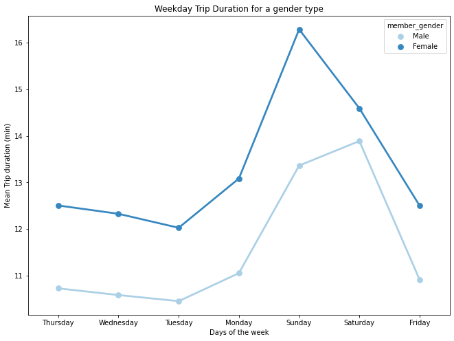

```python
plt.figure(figsize=[11, 8])
sb.pointplot(data = my_data, x = 'Dayofweek', y = 'duration_minutes', hue = 'member_gender', palette = 'Blues', ci=None)
plot_label('Weekday Trip Duration for a gender type','Days of the week','Mean Trip duration (min)')
```

```python
# save all changes made to a new csv
my_data.to_csv('my_Data.csv',
                 index=False, encoding = 'utf-8')
```